# Low-Income Energy Affordability Data

Data for Charlottesville Region

Marisa Lemma

6/25/2021

## Data Source

Source: Low-Income Energy Affordability Data, 2018 Update

- Download URL: https://data.openei.org/submissions/573
- About: https://lead.openei.org/assets/files/LEAD-Tool-Methodology.pdf

## Variable Descriptions

```r
glimpse(lead)
```

```
## Rows: 50
## Columns: 36
## $ FIP                      <dbl> 51003010100, 51003010201, 51003010202, 510030…
## $ county                   <chr> "Albemarle", "Albemarle", "Albemarle", "Albem…
## $ tract                    <dbl> 101.00, 102.01, 102.02, 103.00, 104.01, 104.0…
## $ totalinc                 <dbl> 258861238.7, 183602936.6, 192243103.3, 329144…
## $ totalelep                <dbl> 4257203.1, 3461893.8, 2766898.1, 5307149.1, 4…
## $ totalgas                 <dbl> 1048712.27, 587780.45, 698082.82, 895763.99, …
## $ totalother               <dbl> 5.733480e+05, 1.800686e+05, 2.793150e+05, 1.2…
## $ averageburden            <dbl> 2.271203, 2.303745, 1.947688, 1.923259, 2.919…
## $ lowburden                <dbl> 1750.933158, 1504.638587, 1008.541509, 2810.7…
## $ highburden               <dbl> 190.17722, 133.26387, 76.66867, 147.13759, 29…
## $ veryhighburden           <dbl> 115.88093, 71.29768, 41.89234, 115.82400, 114…
## $ extremelyhighburden      <dbl> 55.616929, 25.143459, 71.777109, 110.487515, …
## $ totalunits               <dbl> 2112.60824, 1734.34359, 1198.87963, 3184.1515…
```

[output cut: 23 more lines]

Observations are census tract estimates of:

- Total income (`totalinc`)
- Total expenditures on electricity, gas, and other energy sources (`totalelep`, `totalgas`, `totalother`)
- Average energy burden (`averageburden`)
  - Energy burden is defined in this data as the percentage of household income spent on energy.
- Number of households that fall in each energy burden category:
  - Low: less than 6% energy burden (`lowburden`)
  - High: 6-10% energy burden (`highburden`)
  - Very high: 10-20% energy burden (`veryhighburden`)
  - Extremely high: 20% energy burden or higher (`extremelyhighburden`)
- Total number of housing units (`totalunits`)
- Total number of energy-burdened households (`numberburdened`)
  - An energy-burdened household is one which falls in the high, very high, or extremely high categories
- Percent of households that are energy-burdened (`percentburdened`)
- Total number of households in each Area Median Income (AMI) category:
  - 0-30%: household income is between 0 and 30% of AMI (`total_0_30`)
  - 30-60%: household income is between 30 and 60% of AMI (`total_30_60`)
  - 60-80%: household income is between 60 and 80% of AMI (`total_60_80`)
  - 80-100%: household income is between 80 and 100% of AMI (`total_80_100`)
  - 100%+: household income is 100% of AMI or greater (`total_over_100`)
- Number of households in each AMI group that are energy burdened (`burdened_0_30`, `burdened_30_60`, `burdened_60_80`, `burdened_80_100`, `burdened_over_100`)
- Percent of households in each AMI group that are energy burdened (`percent_0_30`, `percent_30_60`, `percent_60_80`, `percent_80_100`, `percent_over_100`)
- Total number of households that are owned (`total_owners`)
- Total number of households that are rented (`total_renters`)
- Number of owned households that are energy burdened (`burdened_owners`)
- Number of rented households that are energy burdened (`burdened_renters`)
- Percent of owned households that are energy burdened (`percent_burdened_owners`)
- Percent of rented households that are energy burdened (`percent_burdened_renters`)

## Summaries

Summary of all non-missing variables:

```r
lead %>% select(-c(FIP:tract)) %>%
  select(where(~is.numeric(.x) && !is.na(.x))) %>%
  as.data.frame() %>%
  stargazer(., type = "text", title = "Summary Statistics", digits = 0,
            summary.stat = c("mean", "sd", "min", "median", "max"))
```

```
##
## Summary Statistics
## ===============================================================================
## Statistic                   Mean      St. Dev.    Min     Median        Max
## -------------------------------------------------------------------------------
## totalinc                 177,919,174 90,029,492 662,819 173,393,476 405,427,996
## totalelep                 3,736,593  2,046,840  130,692  3,420,559   8,786,365
## totalgas                   836,745    520,782      0      781,223    2,471,311
## totalother                 184,122    142,104      0      171,001     573,348
## averageburden                 3          3         2         3          20
## lowburden                   1,369       669        1       1,212       3,208
## highburden                   221        147        0        187         650
## veryhighburden               142         95        0        126         443
## extremelyhighburden          112         99        3        85          464
## totalunits                  1,844       789       85       1,752       3,975
## numberburdened               475        274       62        421        1,223
## percentburdened              28          16        6        25          98
## total_0_30                   228        131       39        225         666
## total_30_60                  294        138        0        277         585
## total_60_80                  199        107        0        191         488
## total_80_100                 187        105        0        183         535
## total_over_100               936        489        1        888        2,195
## burdened_0_30                217        128       38        216         647
## burdened_30_60               187        133        0        137         548
## burdened_60_80               48          61        0        27          287
## burdened_80_100              21          35        0        11          185
## burdened_over_100             1          3         0         0          12
## percent_0_30                 95          5        81        96          100
## percent_30_60                62          28       19        64          98
## percent_60_80                24          25        0        13          89
## percent_80_100               10          13        0         7          62
## percent_over_100              0          0         0         0           1
## total_owners                1,248       770       17       1,186       3,459
## total_renters                624        401       68        555        1,667
## burdened_owners              273        231        0        193         892
## burdened_renters             202        143       21        190         681
## percent_burdened_owners      21          16        0        18          100
## percent_burdened_renters     37          20        7        35          98
## -------------------------------------------------------------------------------
```

## Visual Distributions

Visual distributions of the data, shown with histograms

### Trends in Energy Burden

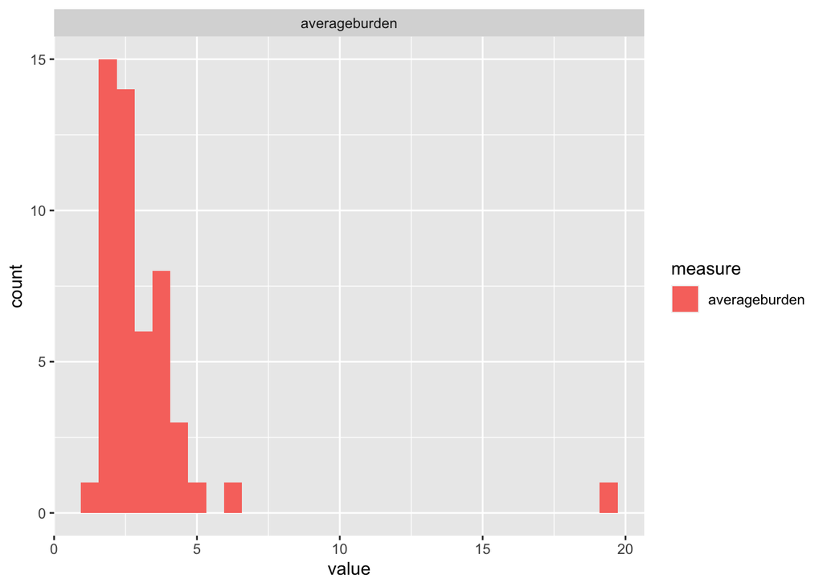

```r
lead %>% select(FIP, averageburden) %>%
  pivot_longer(-FIP, names_to = "measure", values_to = "value") %>%
  ggplot(aes(x = value, fill = measure)) +
  geom_histogram() +
  facet_wrap(~measure, scales = "free")
```

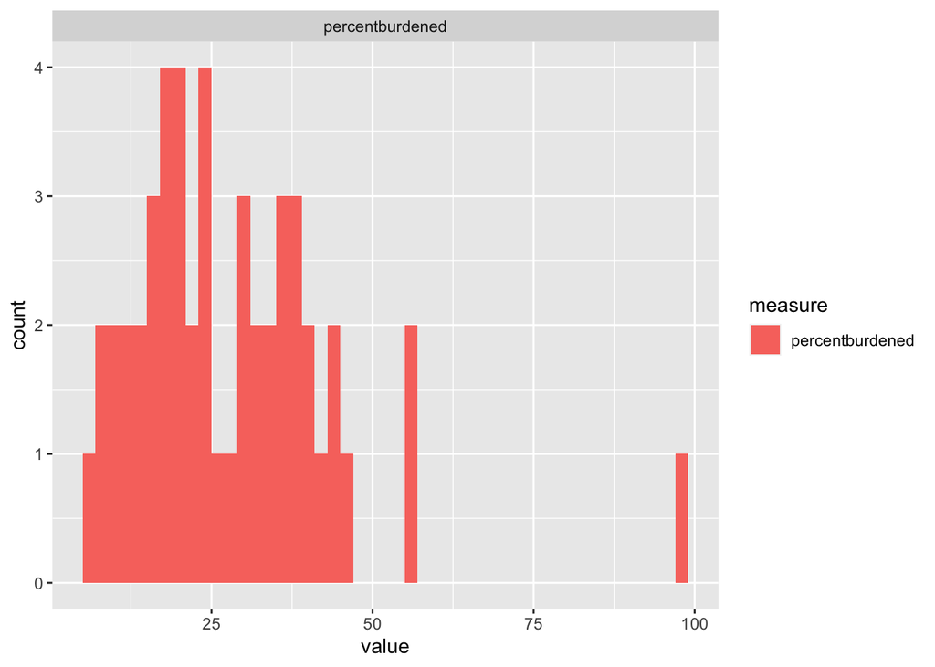

```r
lead %>% select(FIP, percentburdened) %>%
  pivot_longer(-FIP, names_to = "measure", values_to = "value") %>%
  ggplot(aes(x = value, fill = measure)) +
  geom_histogram(binwidth=2) +
  facet_wrap(~measure, scales = "free")
```

### Trends in Energy Burden Across AMI Ranges

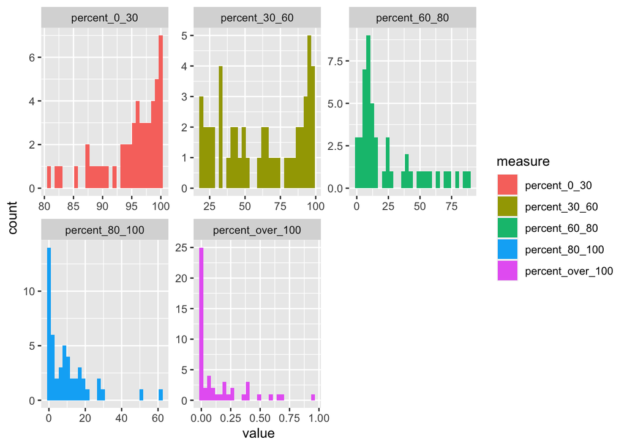

```r
lead %>% select(FIP, percent_0_30:percent_over_100) %>%
  pivot_longer(-FIP, names_to = "measure", values_to = "value") %>%
  ggplot(aes(x = value, fill = measure)) +
  geom_histogram() +
  facet_wrap(~measure, scales = "free")
```

### Trends in Energy Burden by Owning/Renting

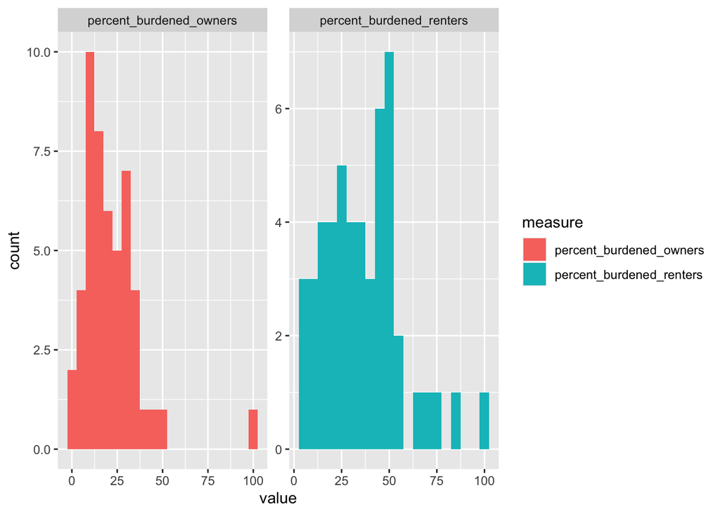

```r
lead %>% select(FIP, percent_burdened_owners, percent_burdened_renters) %>%
  pivot_longer(-FIP, names_to = "measure", values_to = "value") %>%
  ggplot(aes(x = value, fill = measure)) +
  geom_histogram(binwidth = 5) +
  facet_wrap(~measure, scales = "free")
```

## Spatial Distributions

```r
# Open shapefile
cville_tracts <- readOGR('/Users/marisalemma/Downloads/US_Census_Tract_Area_2010/US_Census_Tract_Area_2010.shp', GDAL1_integer64_policy = TRUE)
# Playing around with the spatial data, since I am still new to it
color <- colorNumeric(palette = "Greens",
            domain = as.numeric(cville_tracts$Population))

leaflet(cville_tracts) %>% addProviderTiles(providers$CartoDB.Positron) %>%
  addPolygons(color = ~color(cville_tracts$Population),
              weight = 1,
              smoothFactor = 0.5,
              opacity = 1.0,
              fillOpacity = 0.2,
              highlightOptions =
              highlightOptions(color = "white",
                               weight = 2,
                               bringToFront = TRUE))
```

[interactive chart not shown]